# Data visualisation lab 2

## Made by: Paulius Lapienis

- Data set link: https://www.kaggle.com/datasets/azathoth42/myanimelist
- All of the tasks were performed using the Python programming language.

### Task 1: Describing data types.

- The features used for the visualisations:
  - episodes: ratio, quantitative
  - studio: nominal, quantitative
  - score: ratio, quantitative
  - source: nominal, quantitative

```python
from labs.definitions import DATA_DIR
import pandas as pd

DATA_PATH = DATA_DIR / "anime_filtered.csv"
df = pd.read_csv(DATA_PATH)
df
```

|  | anime_id | title | title_english | title_japanese | title_synonyms | image_url | type | source | episodes | status | ... | background | premiered | broadcast | related | producer | licensor | studio | genre | opening_theme | ending_theme |
| --- | --- | --- | --- | --- | --- | --- | --- | --- | --- | --- | --- | --- | --- | --- | --- | --- | --- | --- | --- | --- | --- |
| 0 | 11013 | Inu x Boku SS | Inu X Boku Secret Service | 妖狐×僕SS | Youko x Boku SS | https://myanimelist.cdn-dena.com/images/anime/... | TV | Manga | 12 | Finished Airing | ... | Inu x Boku SS was licensed by Sentai Filmworks... | Winter 2012 | Fridays at Unknown | {'Adaptation': [{'mal_id': 17207, 'type': 'man... | Aniplex, Square Enix, Mainichi Broadcasting Sy... | Sentai Filmworks | David Production | Comedy, Supernatural, Romance, Shounen | ['"Nirvana" by MUCC'] | ['#1: "Nirvana" by MUCC (eps 1, 11-12)', '#2: ... |
| 1 | 2104 | Seto no Hanayome | My Bride is a Mermaid | 瀬戸の花嫁 | The Inland Sea Bride | https://myanimelist.cdn-dena.com/images/anime/... | TV | Manga | 26 | Finished Airing | ... | NaN | Spring 2007 | Unknown | {'Adaptation': [{'mal_id': 759, 'type': 'manga... | TV Tokyo, AIC, Square Enix, Sotsu | Funimation | Gonzo | Comedy, Parody, Romance, School, Shounen | ['"Romantic summer" by SUN&LUNAR'] | ['#1: "Ashita e no Hikari (明日への光)" by Asuka Hi... |
| 2 | 5262 | Shugo Chara!! Doki | Shugo Chara!! Doki | しゅごキャラ！！どきっ | Shugo Chara Ninenme, Shugo Chara! Second Year | https://myanimelist.cdn-dena.com/images/anime/... | TV | Manga | 51 | Finished Airing | ... | NaN | Fall 2008 | Unknown | {'Adaptation': [{'mal_id': 101, 'type': 'manga... | TV Tokyo, Sotsu | NaN | Satelight | Comedy, Magic, School, Shoujo | ['#1: "Minna no Tamago (みんなのたまご)" by Shugo Cha... | ['#1: "Rottara Rottara (ロッタラ ロッタラ)" by Buono! ... |
| 3 | 721 | Princess Tutu | Princess Tutu | プリンセスチュチュ | NaN | https://myanimelist.cdn-dena.com/images/anime/... | TV | Original | 38 | Finished Airing | ... | Princess Tutu aired in two parts. The first pa... | Summer 2002 | Fridays at Unknown | {'Adaptation': [{'mal_id': 1581, 'type': 'mang... | Memory-Tech, GANSIS, Marvelous AQL | ADV Films | Hal Film Maker | Comedy, Drama, Magic, Romance, Fantasy | ['"Morning Grace" by Ritsuko Okazaki'] | ['"Watashi No Ai Wa Chiisaikeredo" by Ritsuko ... |
| 4 | 12365 | Bakuman. 3rd Season | Bakuman. | バクマン。 | Bakuman Season 3 | https://myanimelist.cdn-dena.com/images/anime/... | TV | Manga | 25 | Finished Airing | ... | NaN | Fall 2012 | Unknown | {'Adaptation': [{'mal_id': 9711, 'type': 'mang... | NHK, Shueisha | NaN | J.C.Staff | Comedy, Drama, Romance, Shounen | ['#1: "Moshimo no Hanashi (もしもの話)" by nano.RIP... | ['#1: "Pride on Everyday" by Sphere (eps 1-13)... |
| ... | ... | ... | ... | ... | ... | ... | ... | ... | ... | ... | ... | ... | ... | ... | ... | ... | ... | ... | ... | ... | ... |
| 14469 | 26089 | Gutchonpa Omoshiro Hanashi | NaN | グッチョンパおもしろ話 | NaN | https://myanimelist.cdn-dena.com/images/anime/... | TV | Unknown | 5 | Finished Airing | ... | NaN | Fall 1987 | Unknown | {'Other': [{'mal_id': 26087, 'type': 'anime', ... | NaN | NaN | NaN | Kids | [] | [] |
| 14470 | 21525 | Geba Geba Shou Time! | NaN | ゲバゲバ笑タイム! | NaN | https://myanimelist.cdn-dena.com/images/anime/... | OVA | Unknown | 1 | Finished Airing | ... | NaN | NaN | NaN | [] | Studio Lotus | NaN | NaN | Comedy | [] | [] |
| 14471 | 37897 | Godzilla: Hoshi wo Kuu Mono | NaN | GODZILLA -星を喰う者- | Godzilla Part 3, Godzilla: Eater of Stars | https://myanimelist.cdn-dena.com/images/anime/... | Movie | Other | 1 | Not yet aired | ... | NaN | NaN | NaN | {'Prequel': [{'mal_id': 36816, 'type': 'anime'... | NaN | NaN | NaN | Action, Sci-Fi, Adventure, Fantasy | [] | [] |
| 14472 | 34193 | Nippon Mukashibanashi: Sannen Netarou | NaN | 日本昔ばなし 三ねん寝太郎 | NaN | https://myanimelist.cdn-dena.com/images/anime/... | OVA | Other | 1 | Finished Airing | ... | NaN | NaN | NaN | [] | NaN | NaN | NaN | Fantasy, Kids | [] | [] |
| 14473 | 37908 | Senjou no Valkyria Special | NaN | 戦場のヴァルキュリア Valkyria Chronicles | Senjou no Valkyria Fake Movie Promo | https://myanimelist.cdn-dena.com/images/anime/... | Special | Unknown | 1 | Finished Airing | ... | NaN | NaN | NaN | {'Other': [{'mal_id': 5507, 'type': 'anime', '... | NaN | NaN | A-1 Pictures | Comedy | [] | [] |

14474 rows × 31 columns

### Task 2: Statistcs (mean, min, max, etc. depending on the data types). Use box plots and other similar plots to illustrate it

The table below shows the statistics of the data set for each feature.

```python
df.drop(columns=['anime_id']).describe()
```

|  | episodes | score | scored_by | rank | popularity | members | favorites |
| --- | --- | --- | --- | --- | --- | --- | --- |
| count | 14474.000000 | 14474.000000 | 1.447400e+04 | 12901.000000 | 14474.000000 | 1.447400e+04 | 14474.000000 |
| mean | 11.310971 | 6.144179 | 1.146319e+04 | 6439.625068 | 7220.277256 | 2.297275e+04 | 311.735595 |
| std | 43.449161 | 1.460617 | 4.311072e+04 | 3719.462602 | 4168.959000 | 7.499075e+04 | 2615.910510 |
| min | 0.000000 | 0.000000 | 0.000000e+00 | 0.000000 | 0.000000 | 0.000000e+00 | 0.000000 |
| 25% | 1.000000 | 5.550000 | 4.600000e+01 | 3218.000000 | 3613.250000 | 2.450000e+02 | 0.000000 |
| 50% | 1.000000 | 6.370000 | 5.010000e+02 | 6442.000000 | 7225.500000 | 1.682500e+03 | 2.000000 |
| 75% | 12.000000 | 7.060000 | 3.947250e+03 | 9664.000000 | 10826.750000 | 1.038050e+04 | 23.000000 |
| max | 1818.000000 | 10.000000 | 1.009477e+06 | 12919.000000 | 14487.000000 | 1.456378e+06 | 106895.000000 |

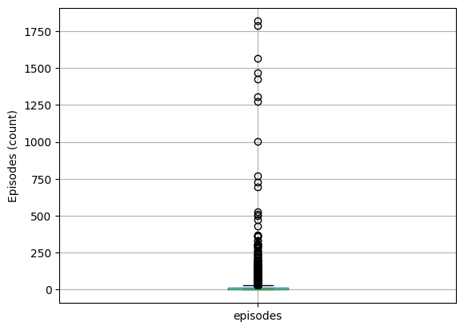

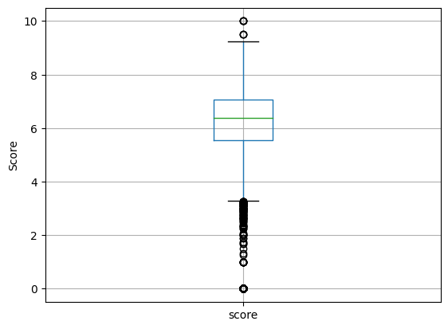

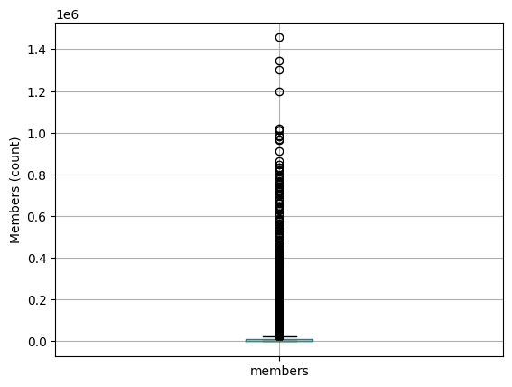

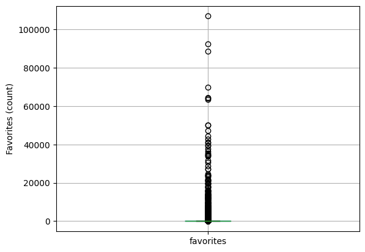

```python
import matplotlib.pyplot as plt

for column in df:
    match column:
        case "score":
            plt.figure()
            ax = df.boxplot([column])
            ax.set_ylabel("Score")
        case "favorites":
            plt.figure()
            ax = df.boxplot([column])
            ax.set_ylabel("Favorites (count)")
        case "episodes":
            plt.figure()
            ax = df.boxplot([column])
            ax.set_ylabel("Episodes (count)")
        case "members":
            plt.figure()
            ax = df.boxplot([column])
            ax.set_ylabel("Members (count)")
```

### Task 3: Create basic visualizations of your data.

Bellow is the score histogram.

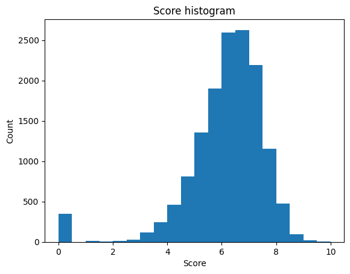

```python
ax = df['score'].plot.hist(bins=20)
ax.set_ylabel("Count")
ax.set_xlabel("Score")
ax.set_title("Score histogram")
```

Bellow is the score relationship with the amount of favorites.

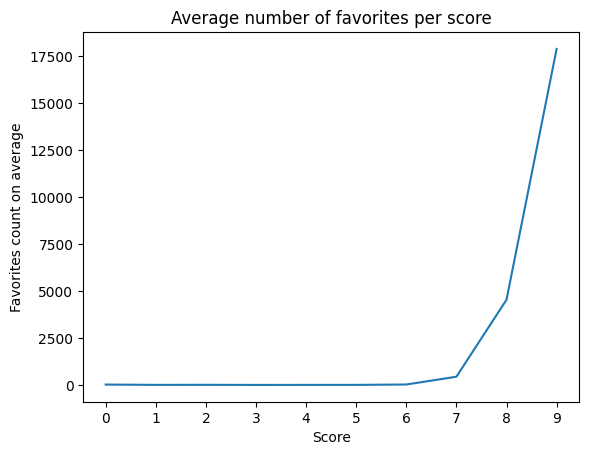

```python
import numpy as np
ax = df.groupby(pd.cut(df["score"], bins=10))["favorites"].mean().plot()
ax.set_xlabel("Score")
ax.set_ylabel("Favorites count on average")
ax.set_xticks(np.arange(0, 10, 1))
ax.set_xticklabels(np.arange(0, 10, 1))
ax.set_title("Average number of favorites per score")
```

Bellow is the histogram for the number of members.

[figure not shown]

```python
ax = df['members'].plot.hist(bins=20)
ax.set_ylabel("Members")
ax.set_xlabel("Count")
ax.set_title("Members histogram")
```

Bellow is a bar graph representing the most popular genres.

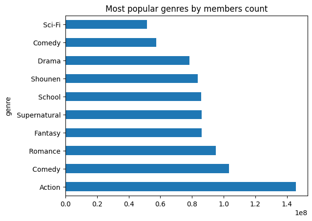

```python
(
    df[["members", "genre"]]
    .dropna()
    .assign(genre=df["genre"].str.split(","))
    .explode(["genre"])
    .groupby("genre")
    .agg([np.sum])
    .sort_values(by=("members", "sum"), ascending=False)
    .head(10)
    .plot(
        kind="barh",
        y="members",
        legend=False,
        title="Most popular genres by members count",
    )
)
```